# **CMU 16825 Learning for 3D Vision – Final Project**

### Implemented Uncertainty Prediction Model: MLP

The following table changes the uncertainty prediction model from 110K-parameter U-Net to a simple two-layer MLP with only 1K parameters. We can check whether the complexity of the uncertainty prediction model is necessary for hybrid rendering fidelity or not.

Uncertainty Models

Camera View Index

Top k% Uncertainty Threshold

Ground-Truth Image

GS Prediction Image

NeRF Prediction Image

SSIM Error Map

Predicted Uncertainty

Mask After Top k% Thresholding

Hybrid Rendering Result

MLP

0

k = 5

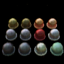

[figure not shown]

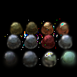

MLP

0

k = 10

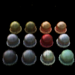

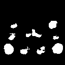

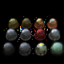

MLP

0

k = 30

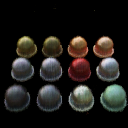

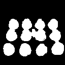

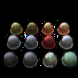

MLP

0

k = 50

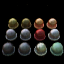

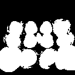

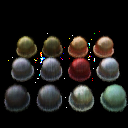

From the table above, we observe the hybrid rendering results using an MLP-based uncertainty predictor across different top ( k% ) thresholds. When (k = 5) and ( 10 ), only a small portion of uncertain regions are re-rendered by NeRF, leading to noticeable fidelity gaps compared to the ground-truth. However, when (k = 30) and (k = 50), the hybrid renderings achieve perceptual quality that is nearly indistinguishable from full NeRF predictions. This demonstrates that re-rendering only 30% to 50% of the pixels based on uncertainty estimation is sufficient to recover high-fidelity details, while the majority of the scene is still efficiently rendered by 3D Gaussian Splatting. The result is very similar to the one using U-Net as the uncertainty prediction model, indicating that simpler model can achieve comparable results in this framework.

The following table shows the 360 degree reconstruction scene using the hybrid rendering with the proposed MLP and top k% uncertained pixels selection:

Uncertainty Models

Top k% Uncertainty Threshold

GS Prediction GIF

NeRF Prediction GIF

Hybrid Rendering GIF

MLP

k = 5

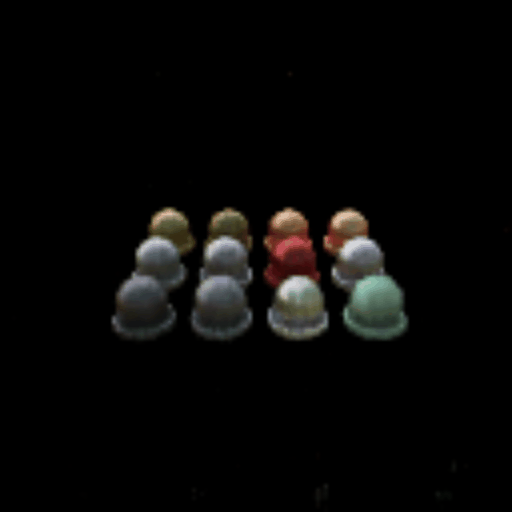

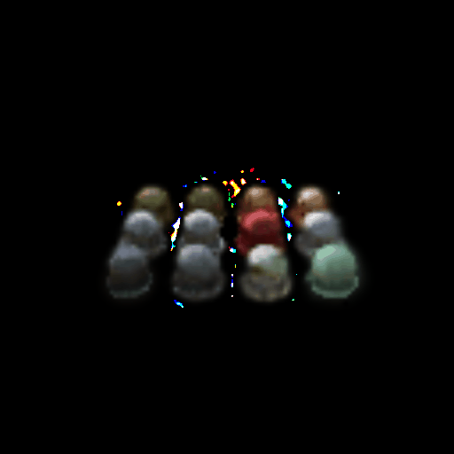

MLP

k = 10

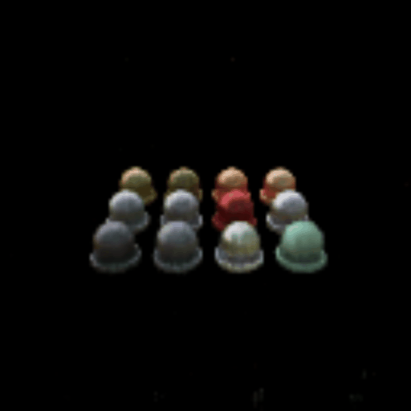

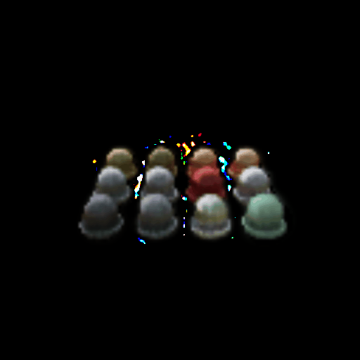

MLP

k = 30

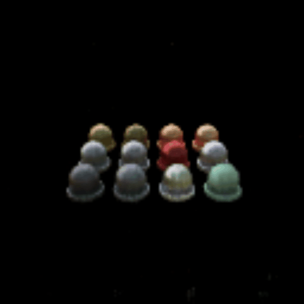

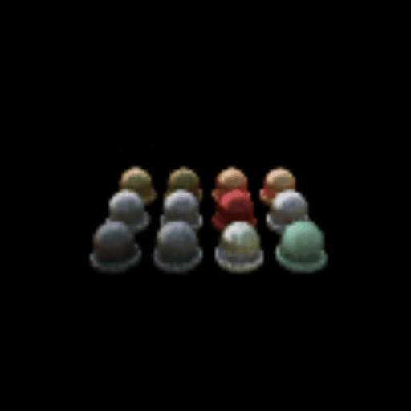

MLP

k = 50

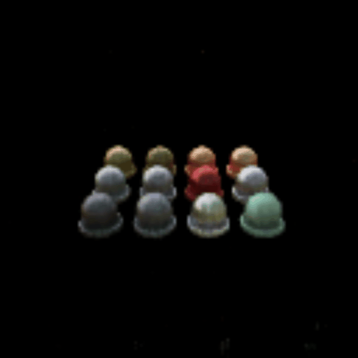

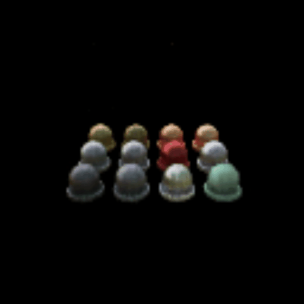

The results above are very similar to those generated by the U-Net model. When (k = 30) or (k = 50), the 360-degree reconstruction remains nearly identical to full NeRF rendering. The hybrid method achieves comparable fidelity, while the majority of pixels are still rendered by Gaussian Splatting. This demonstrates that refining only 30% or 50% of pixels with NeRF is sufficient to maintain high perceptual quality. Moreover, it shows that the uncertainty prediction model does not need to be complex, as even a lightweight MLP can achieve strong fidelity.

### More Rendering Results Using These Two Models Under Different Camera Views

As k = 30 could provide high fidelity resutls, we further view the hybrid rendering results with k = 30 under different camera views (by changing the camera view index in the test dataset). The following table shows the results.

Uncertainty Models

Camera View Index

Top k% Uncertainty Threshold

Ground-Truth Image

GS Prediction Image

NeRF Prediction Image

SSIM Error Map

Predicted Uncertainty

Mask After Top k% Thresholding

Hybrid Rendering Result

U-Net

20

k = 30

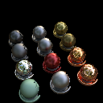

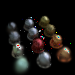

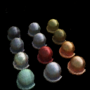

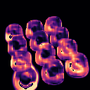

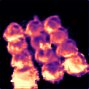

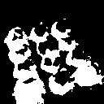

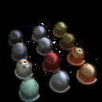

MLP

20

k = 30

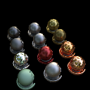

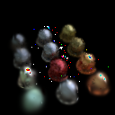

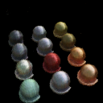

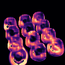

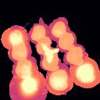

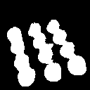

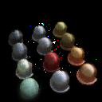

U-Net

40

k = 30

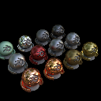

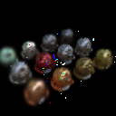

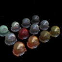

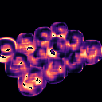

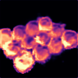

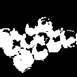

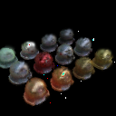

MLP

40

k = 30

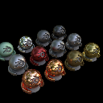

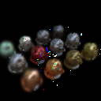

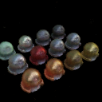

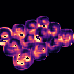

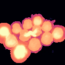

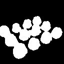

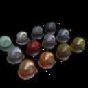

U-Net

60

k = 30

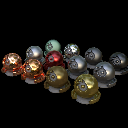

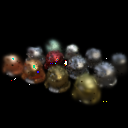

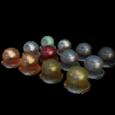

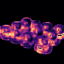

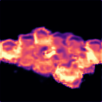

[figure not shown]

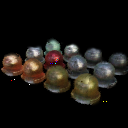

MLP

60

k = 30

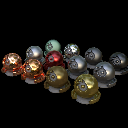

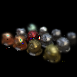

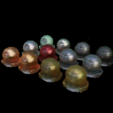

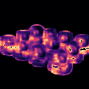

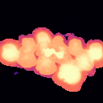

[figure not shown]

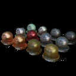

Across different camera views, the hybrid rendering results with (k = 30) consistently achieve high perceptual quality. Both U-Net and MLP-based uncertainty models effectively identify uncertain regions, allowing the hybrid system to selectively refine key pixels with NeRF. Despite the MLP having significantly fewer parameters, its results remain comparable to those of the U-Net across multiple views. This demonstrates that our uncertainty-aware hybrid framework is robust to changes in viewpoint and that lightweight uncertainty models are sufficient to maintain high rendering fidelity.

# Quantitative Results

The following table summarizes the rendering quality and runtime results with Gaussian Splatting method only (GS only), NeRF method only (NeRF only), SS Mip-NeRF method, and our hybrid rendering method at different replacement rates with MLP and U-Net models for uncertainty prediction:

| Method | PSNR↑ | SSIM↑ | GS Time (s) | NeRF Time (s) | Total Time (s) | Replace % |
| --- | --- | --- | --- | --- | --- | --- |
| GS only | 22.23 | 0.819 | 0.246 | - | 0.246 | 0% |
| NeRF only | 24.76 | 0.891 | - | 0.827 | 0.827 | 100% |
| SS Mip-NeRF | 32.60 | - | - | 0.864 | 0.864 | 100% |
| Hybrid-MLP 5% | 22.39 | 0.824 | 0.272 | 0.040 | 0.312 | ~5% |
| Hybrid-MLP 10% | 22.64 | 0.832 | 0.272 | 0.081 | 0.353 | ~10% |
| Hybrid-MLP 30% | 24.31 | 0.875 | 0.272 | 0.220 | 0.492 | ~30% |
| Hybrid-MLP 50% | 24.75 | 0.892 | 0.271 | 0.397 | 0.668 | ~50% |
| Hybrid-UNet 5% | 22.58 | 0.836 | 0.275 | 0.040 | 0.315 | ~5% |
| Hybrid-UNet 10% | 22.88 | 0.847 | 0.274 | 0.079 | 0.353 | ~10% |
| Hybrid-UNet 30% | 24.11 | 0.880 | 0.274 | 0.220 | 0.494 | ~30% |
| Hybrid-UNet 50% | 24.73 | 0.892 | 0.274 | 0.399 | 0.673 | ~50% |

**Note:**

- GS Time refers to the time spent on feature extraction using the GS model.
- NeRF Time refers to the time spent on ray-marching and rendering using NeRF for selected pixels.

We further analyze the feature extraction cost with $k=50$ (Replace 50%) as the following tables, the first one is using the Hybrid-UNet model:

| Steps | Time (s) | Percentage |
| --- | --- | --- |
| whole feature extraction | 0.2740 | 100% |
| compute alpha sum | 0.2180 | 79.56% |
| compute color variance | 0.0350 | 12.77% |
| compute 2D covariance (proj_gau) | 0.0080 | 2.92% |
| compute 2D covariance area (footprint_area) | 0.0040 | 1.46% |
| compute view direction | 0.0034 | 1.24% |
| model feed forward | 0.0033 | 1.20% |
| compute depth and sorting | 0.0010 | 0.36% |
| select top-k and mask | 0.0009 | 0.34% |
| flatten | 0.0004 | 0.15% |

The second table below shows the profiling of the feature extraction cost with $k=50$ (Replace 50%) using the Hybrid-MLP model:

| Steps | Time (s) | Percentage |
| --- | --- | --- |
| whole feature extraction | 0.2710 | 100% |
| compute alpha sum | 0.2170 | 80.07% |
| compute color variance | 0.0350 | 12.92% |
| compute 2D covariance (proj_gau) | 0.0080 | 2.95% |
| compute 2D covariance area (footprint_area) | 0.0040 | 1.48% |
| compute view direction | 0.0034 | 1.25% |
| model feed forward | 0.0013 | 0.48% |
| compute depth and sorting | 0.0010 | 0.37% |
| select top-k and mask | 0.0009 | 0.33% |
| flatten | 0.0004 | 0.15% |

The profiling of the feature extraction process for both the Hybrid-UNet and Hybrid-MLP models shows that most of the time is spent on **alpha sum computation** (∼80%) and **color variance** (∼13%), with all other steps contributing less than 3%.

Hybrid-MLP is slightly faster overall (0.2710s vs. 0.2740s) due to its smaller model and faster inference (0.0013s vs. 0.0033s). Despite this, both models share nearly identical time breakdowns, indicating that the main bottleneck lies in **feature computation** (especially alpha sum), not model complexity.

# References

[1] Ben Mildenhall, Pratul P. Srinivasan, Matthew Tancik, Jonathan T. Barron, Ravi Ramamoorthi, and Ren Ng.  
NeRF: Representing scenes as neural radiance fields for view synthesis.  
In *ECCV*, 2020.

[2] Bernhard Kerbl, Georgios Kopanas, Thomas Leimkühler, and George Drettakis.  
3D Gaussian Splatting for Real-Time Radiance Field Rendering.  
*ACM Transactions on Graphics (TOG)*, 42(4), July 2023.

[3] Jonathan T. Barron, Ben Mildenhall, Matthew Tancik, Peter Hedman, Ricardo Martin-Brualla, and Pratul P. Srinivasan.  
Mip-NeRF: A multiscale representation for anti-aliasing neural radiance fields, 2021.